# **Video Game Sales**

## Summer 2026 Data Science Project

### Jerico Estrella, Tanush Parhi, Ronit Munshi, Jake Glendon, Sang Pham

### **1) Contributions:**

##### A: Project idea

- Tanush Parhi: Proposed the idea of analyzing video games sales across different platforms, years, regions, and genres.

##### B: Dataset Curation and Preprocessing

- Tanush Parhi: Found the first dataset on video games sales from 1980-2016.
- Ronit Munshi - Dataset #1: Transform dataset into a dataframe, then organize it for consistent formatting, remove unusable columns or null values, and fill in missing values to prepare it for merging.
- Jerico Estrella (Dataset #2/Merging Data): Found the second dataset on video games sales that goes up to 2024. Transform dataset into a dataframe cleaning for consistent formatting then merge/combine the two dataframes into one handling duplicates and missing values.

#### C: Data Exploration and Summary Statistics

- Jake Glendon (Conclusion #2):

We begin by exploring the dataset's characteristics using descriptive statistics, which reveal a strong right-skew in total game sales across all platforms. Most titles generate relatively low sales, whereas a select few blockbuster games drive disproportionately high values. A prime example of this extreme volatility is Wii Sports, which stands out as a massive outlier with approximately 82.53 million units sold. This extreme skewness and high variability suggest that sales are unevenly distributed and heavily influenced by a handful of hit titles, though a noticeable relationship remains between categorical features like platform choice and overall sales performance. To evaluate whether platform choice significantly impacts sales, we utilized statistical hypothesis testing, though the data's inherent skewness requires careful interpretation. A Levene’s test confirmed that variance is not equal across platforms (W = 12.24, p = 1.08*10^(-75), violating standard assumptions. Despite this, an ANOVA test was conducted to compare mean sales, yielding highly significant results (F = 25.23, p = 1.33* 10^(-132)). Because the p-value is well below 0.05, we reject the null hypothesis, confirming that platform does have a statistically significant effect on sales.

- Sang Pham (Conclusion #3):

To investigate whether release year has an effect on total global sales, Spearman rank correlation, linear regression, and Mann Whitney U were conducted. Because the total sales are heavily right skewed, with a small number of blockbuster titles inflating the mean, Spearman rank correlation was chosen as it is more robust to skewed distribution compared to something like Pearson. The Spearman test returned a correlation of p=-0.20 with p<0.001, which is well below the 0.05 significance threshold, so the null hypothesis was rejected and it was concluded that there is a significant negative monotonic relationship between release year and total sales. Linear regression on log transformed sales further confirmed this, returning a slope of -0.025 log units per year (p<0.001), meaning each additional year of release is associated with roughly a 5.6% decrease in sales per title on average. Finally, a Mann Whitney U test was used to directly compare the two eras without any normality assumptions, showing that early era games from 1995-2006 with a median of 0.19M statistically outsold late era games from 2007 to 2018 with a median of 0.12M (p<0.001). The violin plot confirms the same pattern visually. The early era violins are wider and sit higher with more mass above the 0.1M mark, while the late era violins compress and shift downward. The most likely explanation is market saturation, as the number of games released per year grew from around 216 in 1995 to over 1,500 by 2008 and 2009, which splits consumer spendings across far more titles at once. This finding also has implications for the rest of the analysis, as release year should be treated as a control variable since older platforms and genres may appear to perform better simply because they faced less competition at the time rather than anything related to the genre or platform itself.

#### D: ML Algorithm Design/Development

- Tanush: Selected the Random Forest Regression technique for this analysis, since it can process both categorical and numerical characteristics (like genre, platform, etc.) regardless of whether they are independent or not (also resistant to outliers and overfitting). Ensured this design was a good fit for the project as we wanted to measure the importance of the factors used in predicting the game’s total sales.

#### E: ML Algorithm Training and Test Data Analysis

- Tanush: Performed the initial stage of the machine learning training process by choosing independent variables needed to make total sales predictions (genre, platform, and year released). Converted categorical variables to one-hot indicators, divided the data set into an 80%-20% training-testing split, and used a Random Forest Regressor with 200 trees to conduct the training process.
- Sang: Built on top of the data preparation and model training cell by creating predictions on the test set using the trained Random Forest Regressor. Evaluated model performance using R², MSE, and RMSE, and interpreted the results and relating it back to the research question.

##### F: Visualization, Result Analysis, Conclusion

- Jake: Made a horizontal bar chart to better understand which factors were the most important predictors of video game sales. The chart shows that the release year is the most important factor for predicted video game sales, followed by genre and then platform. This suggests that changes in the market, over time, have the largest impact on predicted video game sales.
- Jerico: Wrote the insights and conclusion summarizing project and our findings of the features of release year, genre, and platform on total video games sales

##### G: Final Tutorial Report Creation

- Jerico: Combined all sections of the project into one final self-contained tutorial, mixing Markdown prose and Python code, and published it as a GitHub statically-hosted Page.
- Ronit: Added to the Introduction to introduce relevant information about the current state of the Video Game industry that relates to the topic of creating a good-selling video game.

```python
# import libraries
import pandas as pd
from datetime import datetime
import string
```

### **2) Introduction**

The video game industry has drastically evolved over the decades, from the earliest home platforms like the NES and Game Boy in the 1980s to the modern landscape of the mid-2020s dominated by high-performance PCs and consoles such as the PS5 and Xbox Series X. Over this time, the commercial success of a video game is often measured by its total sales worldwide which is often determined by a number of different factors, including genre, platform, publisher, release year, region sales, and critic score.

Behind every game, from the worst to the best, we wanted to determine whether any one of these factors has a meaningful impact on a game's total sales. Specifically, we focus on three key variables and their impact on the total sales of a video game across genre, platform, and release year. Using this knowledge, we wanted to build a model to predict the level of future success of video games, whether in development or at the brainstorming stage, based on their total sales and these factors.

Answering these questions matters beyond pure curiosity. In the background, there's a lot that goes into making video games, from getting investors to fund the project, planning the game's outline, building and developing the game, testing it, and then marketing it to the general public, which takes a lot of time and money. So, when investing in these games, you need to properly evaluate and plan and developers operating in an increasingly competitive industry, understanding which factors drive total sales can inform smarter decisions, such as which platform to build the game on, what type of game it should be, where to release it, and especially the budget.

As of late in the gaming industry, there have been cases where the budgets for games are over-inflated to the point where even if the game sells well, they aren’t able to recoup the cost, leading to layoffs and potentially full closures of the studios who develop said games. Some specific examples include games like Battlefield 6, which had a very successful launch back in October 2025, beating out that year’s Call of Duty, Black Ops 7, in terms of total concurrent player count. Yet despite this success, there were numerous layoffs at EA across the studios involved in developing the game. And a smaller example would be former studio Douze Dixième, who had released their game Mio: Memories in Orbit earlier this year. While critically successful based on the reviews, the studio did shut down this year as a result of the game not selling enough. Looking at the PC games platform Steam, 21,397 games released in 2025 on the platform alone, not accounting for all the older games as well, so making sure that keeping budgets in check is important based on the factors that we used later on.

### **3) Data Curation**

For our data, we chose datasets from Kaggle related to video game sales and their markets. For the first dataset by Kirubi, it covers and analyzes video game sales from 1980 to 2016, which includes columns such as name, platform, year of release, genre, publisher, North America sales, Europe sales, Japan sales, other sales, global sales, critic score, critic count, user_score, user_count, developer, and rating (Kirubi, 2016). The second dataset we found by Bohdan covers a broader and higher range of video games going up to 2024, analyzing each game’s market, which includes columns like image of game, title, console, genre, publisher, developer, critic_score, total_sales, north america sales, japan sales, europe sales, other sales, release date, and last update (Bohdan, 2025) . We decided to use both datasets because they would be useful for analyzing data, help include a broader range of video games, provide more analysis over the four decades of the video game industry, and fill any missing values or gaps in either dataset,  When preprocessing or transforming data, we import the datasets and convert them to dataframes. Then we parse and organize each dataframe, ensuring we extract useful columns and identify features or characteristics that are present and match across the dataframes, such as game name and platform. Next, we ensure that each dataframe has the same style and values by converting all string values to lowercase, rewriting column titles to match, extracting only the years from datetime objects as integers, dropping and filtering unneeded data or duplicates, and filling any empty values. Before merging, we first check whether the string values in both dataframes are in a similar format, so it's easier to drop duplicates of the same game. Once the merge was complete, we also added a new column with five categories that determined each game's sales level from poor, low, medium, high, and hit. We sorted each game's total sales into one of these categories so a game with total sales of 0.15 falls into the low category. We do this to fill in missing critic scores by grouping games by both genre and sales level, then using the median critic score for each group to replace the missing values.

#### **Sources**:

Kirubi, R. (2016). Video Game Sales with Ratings. www.kaggle.com. https://www.kaggle.com/datasets/rush4ratio/video-game-sales-with-ratings

Bohdan. (2025, September 10). Video Game market analysis 1971-2024. Kaggle.com; Kaggle. https://www.kaggle.com/code/bohdandem/video-game-market-analysis-1971-2024/input?select=vgchartz-2024.csv

### **Data preprocessing**

#### **Dataset #1**

(a) import

```python
df1 = pd.read_csv("VideoGamesSales-2016.csv")
print(df1.shape)
print(df1.dtypes)
display(df1)
```

```
(16719, 16)
Name                object
Platform            object
Year_of_Release    float64
Genre               object
Publisher           object
NA_Sales           float64
EU_Sales           float64
JP_Sales           float64
Other_Sales        float64
Global_Sales       float64
Critic_Score       float64
Critic_Count       float64
User_Score          object
User_Count         float64
Developer           object
Rating              object
dtype: object
```

|  | Name | Platform | Year_of_Release | Genre | Publisher | NA_Sales | EU_Sales | JP_Sales | Other_Sales | Global_Sales | Critic_Score | Critic_Count | User_Score | User_Count | Developer | Rating |
| --- | --- | --- | --- | --- | --- | --- | --- | --- | --- | --- | --- | --- | --- | --- | --- | --- |
| 0 | Wii Sports | Wii | 2006.0 | Sports | Nintendo | 41.36 | 28.96 | 3.77 | 8.45 | 82.53 | 76.0 | 51.0 | 8 | 322.0 | Nintendo | E |
| 1 | Super Mario Bros. | NES | 1985.0 | Platform | Nintendo | 29.08 | 3.58 | 6.81 | 0.77 | 40.24 | NaN | NaN | NaN | NaN | NaN | NaN |
| 2 | Mario Kart Wii | Wii | 2008.0 | Racing | Nintendo | 15.68 | 12.76 | 3.79 | 3.29 | 35.52 | 82.0 | 73.0 | 8.3 | 709.0 | Nintendo | E |
| 3 | Wii Sports Resort | Wii | 2009.0 | Sports | Nintendo | 15.61 | 10.93 | 3.28 | 2.95 | 32.77 | 80.0 | 73.0 | 8 | 192.0 | Nintendo | E |
| 4 | Pokemon Red/Pokemon Blue | GB | 1996.0 | Role-Playing | Nintendo | 11.27 | 8.89 | 10.22 | 1.00 | 31.37 | NaN | NaN | NaN | NaN | NaN | NaN |
| ... | ... | ... | ... | ... | ... | ... | ... | ... | ... | ... | ... | ... | ... | ... | ... | ... |
| 16714 | Samurai Warriors: Sanada Maru | PS3 | 2016.0 | Action | Tecmo Koei | 0.00 | 0.00 | 0.01 | 0.00 | 0.01 | NaN | NaN | NaN | NaN | NaN | NaN |
| 16715 | LMA Manager 2007 | X360 | 2006.0 | Sports | Codemasters | 0.00 | 0.01 | 0.00 | 0.00 | 0.01 | NaN | NaN | NaN | NaN | NaN | NaN |
| 16716 | Haitaka no Psychedelica | PSV | 2016.0 | Adventure | Idea Factory | 0.00 | 0.00 | 0.01 | 0.00 | 0.01 | NaN | NaN | NaN | NaN | NaN | NaN |
| 16717 | Spirits & Spells | GBA | 2003.0 | Platform | Wanadoo | 0.01 | 0.00 | 0.00 | 0.00 | 0.01 | NaN | NaN | NaN | NaN | NaN | NaN |
| 16718 | Winning Post 8 2016 | PSV | 2016.0 | Simulation | Tecmo Koei | 0.00 | 0.00 | 0.01 | 0.00 | 0.01 | NaN | NaN | NaN | NaN | NaN | NaN |

16719 rows × 16 columns

(b) parse

```python
# makes all the string data in lowercase and makes sure any whitespace is removed
df1["Name"] = df1["Name"].str.lower().str.strip()
df1["Platform"] = df1["Platform"].str.lower().str.strip()
df1["Publisher"] = df1["Publisher"].str.lower().str.strip()
df1["Genre"] = df1["Genre"].str.lower().str.strip()
df1["Developer"] = df1["Developer"].str.lower().str.strip()
df1["Rating"] = df1["Rating"].str.lower().str.strip()

display(df1)
```

|  | Name | Platform | Year_of_Release | Genre | Publisher | NA_Sales | EU_Sales | JP_Sales | Other_Sales | Global_Sales | Critic_Score | Critic_Count | User_Score | User_Count | Developer | Rating |
| --- | --- | --- | --- | --- | --- | --- | --- | --- | --- | --- | --- | --- | --- | --- | --- | --- |
| 0 | wii sports | wii | 2006.0 | sports | nintendo | 41.36 | 28.96 | 3.77 | 8.45 | 82.53 | 76.0 | 51.0 | 8 | 322.0 | nintendo | e |
| 1 | super mario bros. | nes | 1985.0 | platform | nintendo | 29.08 | 3.58 | 6.81 | 0.77 | 40.24 | NaN | NaN | NaN | NaN | NaN | NaN |
| 2 | mario kart wii | wii | 2008.0 | racing | nintendo | 15.68 | 12.76 | 3.79 | 3.29 | 35.52 | 82.0 | 73.0 | 8.3 | 709.0 | nintendo | e |
| 3 | wii sports resort | wii | 2009.0 | sports | nintendo | 15.61 | 10.93 | 3.28 | 2.95 | 32.77 | 80.0 | 73.0 | 8 | 192.0 | nintendo | e |
| 4 | pokemon red/pokemon blue | gb | 1996.0 | role-playing | nintendo | 11.27 | 8.89 | 10.22 | 1.00 | 31.37 | NaN | NaN | NaN | NaN | NaN | NaN |
| ... | ... | ... | ... | ... | ... | ... | ... | ... | ... | ... | ... | ... | ... | ... | ... | ... |
| 16714 | samurai warriors: sanada maru | ps3 | 2016.0 | action | tecmo koei | 0.00 | 0.00 | 0.01 | 0.00 | 0.01 | NaN | NaN | NaN | NaN | NaN | NaN |
| 16715 | lma manager 2007 | x360 | 2006.0 | sports | codemasters | 0.00 | 0.01 | 0.00 | 0.00 | 0.01 | NaN | NaN | NaN | NaN | NaN | NaN |
| 16716 | haitaka no psychedelica | psv | 2016.0 | adventure | idea factory | 0.00 | 0.00 | 0.01 | 0.00 | 0.01 | NaN | NaN | NaN | NaN | NaN | NaN |
| 16717 | spirits & spells | gba | 2003.0 | platform | wanadoo | 0.01 | 0.00 | 0.00 | 0.00 | 0.01 | NaN | NaN | NaN | NaN | NaN | NaN |
| 16718 | winning post 8 2016 | psv | 2016.0 | simulation | tecmo koei | 0.00 | 0.00 | 0.01 | 0.00 | 0.01 | NaN | NaN | NaN | NaN | NaN | NaN |

16719 rows × 16 columns

```python
# drops any sales that are NULL
df1 = df1.dropna(subset=["Global_Sales"])
# drops any duplucaite row entries
df1 = df1.drop_duplicates()
# only used rows where total sales greater than 0
df1 = df1[df1["Global_Sales"] > 0]

print(df1.shape)
display(df1)
```

```
(16719, 16)
```

|  | Name | Platform | Year_of_Release | Genre | Publisher | NA_Sales | EU_Sales | JP_Sales | Other_Sales | Global_Sales | Critic_Score | Critic_Count | User_Score | User_Count | Developer | Rating |
| --- | --- | --- | --- | --- | --- | --- | --- | --- | --- | --- | --- | --- | --- | --- | --- | --- |
| 0 | wii sports | wii | 2006.0 | sports | nintendo | 41.36 | 28.96 | 3.77 | 8.45 | 82.53 | 76.0 | 51.0 | 8 | 322.0 | nintendo | e |
| 1 | super mario bros. | nes | 1985.0 | platform | nintendo | 29.08 | 3.58 | 6.81 | 0.77 | 40.24 | NaN | NaN | NaN | NaN | NaN | NaN |
| 2 | mario kart wii | wii | 2008.0 | racing | nintendo | 15.68 | 12.76 | 3.79 | 3.29 | 35.52 | 82.0 | 73.0 | 8.3 | 709.0 | nintendo | e |
| 3 | wii sports resort | wii | 2009.0 | sports | nintendo | 15.61 | 10.93 | 3.28 | 2.95 | 32.77 | 80.0 | 73.0 | 8 | 192.0 | nintendo | e |
| 4 | pokemon red/pokemon blue | gb | 1996.0 | role-playing | nintendo | 11.27 | 8.89 | 10.22 | 1.00 | 31.37 | NaN | NaN | NaN | NaN | NaN | NaN |
| ... | ... | ... | ... | ... | ... | ... | ... | ... | ... | ... | ... | ... | ... | ... | ... | ... |
| 16714 | samurai warriors: sanada maru | ps3 | 2016.0 | action | tecmo koei | 0.00 | 0.00 | 0.01 | 0.00 | 0.01 | NaN | NaN | NaN | NaN | NaN | NaN |
| 16715 | lma manager 2007 | x360 | 2006.0 | sports | codemasters | 0.00 | 0.01 | 0.00 | 0.00 | 0.01 | NaN | NaN | NaN | NaN | NaN | NaN |
| 16716 | haitaka no psychedelica | psv | 2016.0 | adventure | idea factory | 0.00 | 0.00 | 0.01 | 0.00 | 0.01 | NaN | NaN | NaN | NaN | NaN | NaN |
| 16717 | spirits & spells | gba | 2003.0 | platform | wanadoo | 0.01 | 0.00 | 0.00 | 0.00 | 0.01 | NaN | NaN | NaN | NaN | NaN | NaN |
| 16718 | winning post 8 2016 | psv | 2016.0 | simulation | tecmo koei | 0.00 | 0.00 | 0.01 | 0.00 | 0.01 | NaN | NaN | NaN | NaN | NaN | NaN |

16719 rows × 16 columns

```python
# converts the year column to Int64 integers from floats, with any NaNs becoming nullable ints
df1["Year_of_Release"] = pd.to_numeric(df1['Year_of_Release'], errors='coerce').astype('Int64')
# makes sure that the user score stays in its numeric float64 types
df1["User_Score"] = pd.to_numeric(df1['User_Score'], errors='coerce')

print(df1.dtypes)
display(df1)
```

```
Name                object
Platform            object
Year_of_Release      Int64
Genre               object
Publisher           object
NA_Sales           float64
EU_Sales           float64
JP_Sales           float64
Other_Sales        float64
Global_Sales       float64
Critic_Score       float64
Critic_Count       float64
User_Score         float64
User_Count         float64
Developer           object
Rating              object
dtype: object
```

|  | Name | Platform | Year_of_Release | Genre | Publisher | NA_Sales | EU_Sales | JP_Sales | Other_Sales | Global_Sales | Critic_Score | Critic_Count | User_Score | User_Count | Developer | Rating |
| --- | --- | --- | --- | --- | --- | --- | --- | --- | --- | --- | --- | --- | --- | --- | --- | --- |
| 0 | wii sports | wii | 2006 | sports | nintendo | 41.36 | 28.96 | 3.77 | 8.45 | 82.53 | 76.0 | 51.0 | 8.0 | 322.0 | nintendo | e |
| 1 | super mario bros. | nes | 1985 | platform | nintendo | 29.08 | 3.58 | 6.81 | 0.77 | 40.24 | NaN | NaN | NaN | NaN | NaN | NaN |
| 2 | mario kart wii | wii | 2008 | racing | nintendo | 15.68 | 12.76 | 3.79 | 3.29 | 35.52 | 82.0 | 73.0 | 8.3 | 709.0 | nintendo | e |
| 3 | wii sports resort | wii | 2009 | sports | nintendo | 15.61 | 10.93 | 3.28 | 2.95 | 32.77 | 80.0 | 73.0 | 8.0 | 192.0 | nintendo | e |
| 4 | pokemon red/pokemon blue | gb | 1996 | role-playing | nintendo | 11.27 | 8.89 | 10.22 | 1.00 | 31.37 | NaN | NaN | NaN | NaN | NaN | NaN |
| ... | ... | ... | ... | ... | ... | ... | ... | ... | ... | ... | ... | ... | ... | ... | ... | ... |
| 16714 | samurai warriors: sanada maru | ps3 | 2016 | action | tecmo koei | 0.00 | 0.00 | 0.01 | 0.00 | 0.01 | NaN | NaN | NaN | NaN | NaN | NaN |
| 16715 | lma manager 2007 | x360 | 2006 | sports | codemasters | 0.00 | 0.01 | 0.00 | 0.00 | 0.01 | NaN | NaN | NaN | NaN | NaN | NaN |
| 16716 | haitaka no psychedelica | psv | 2016 | adventure | idea factory | 0.00 | 0.00 | 0.01 | 0.00 | 0.01 | NaN | NaN | NaN | NaN | NaN | NaN |
| 16717 | spirits & spells | gba | 2003 | platform | wanadoo | 0.01 | 0.00 | 0.00 | 0.00 | 0.01 | NaN | NaN | NaN | NaN | NaN | NaN |
| 16718 | winning post 8 2016 | psv | 2016 | simulation | tecmo koei | 0.00 | 0.00 | 0.01 | 0.00 | 0.01 | NaN | NaN | NaN | NaN | NaN | NaN |

16719 rows × 16 columns

```python
# makes sure that the Critic_Score stays in its numeric float64 types
df1['Critic_Score'] = pd.to_numeric(df1['Critic_Score'], errors='coerce')

# Converts the critics_count and user-count columns to Int64 since they are whole numbers
# with any NaNs being converted to nullable integers
df1['Critic_Count'] = pd.to_numeric(df1['Critic_Count'], errors='coerce').astype('Int64')
df1['User_Count'] = pd.to_numeric(df1['User_Count'], errors='coerce').astype('Int64')

# makes sure the sales data is still in the form of float64 decimals
df1['JP_Sales'] = pd.to_numeric(df1['JP_Sales'], errors='coerce')
df1['NA_Sales'] = pd.to_numeric(df1['NA_Sales'], errors='coerce')
df1['EU_Sales'] = pd.to_numeric(df1['EU_Sales'], errors='coerce')
df1['Other_Sales'] = pd.to_numeric(df1['Other_Sales'], errors='coerce')
df1['Global_Sales'] = pd.to_numeric(df1['Global_Sales'], errors='coerce')

print(df1.dtypes)
display(df1)
```

```
Name                object
Platform            object
Year_of_Release      Int64
Genre               object
Publisher           object
NA_Sales           float64
EU_Sales           float64
JP_Sales           float64
Other_Sales        float64
Global_Sales       float64
Critic_Score       float64
Critic_Count         Int64
User_Score         float64
User_Count           Int64
Developer           object
Rating              object
dtype: object
```

|  | Name | Platform | Year_of_Release | Genre | Publisher | NA_Sales | EU_Sales | JP_Sales | Other_Sales | Global_Sales | Critic_Score | Critic_Count | User_Score | User_Count | Developer | Rating |
| --- | --- | --- | --- | --- | --- | --- | --- | --- | --- | --- | --- | --- | --- | --- | --- | --- |
| 0 | wii sports | wii | 2006 | sports | nintendo | 41.36 | 28.96 | 3.77 | 8.45 | 82.53 | 76.0 | 51 | 8.0 | 322 | nintendo | e |
| 1 | super mario bros. | nes | 1985 | platform | nintendo | 29.08 | 3.58 | 6.81 | 0.77 | 40.24 | NaN | <NA> | NaN | <NA> | NaN | NaN |
| 2 | mario kart wii | wii | 2008 | racing | nintendo | 15.68 | 12.76 | 3.79 | 3.29 | 35.52 | 82.0 | 73 | 8.3 | 709 | nintendo | e |
| 3 | wii sports resort | wii | 2009 | sports | nintendo | 15.61 | 10.93 | 3.28 | 2.95 | 32.77 | 80.0 | 73 | 8.0 | 192 | nintendo | e |
| 4 | pokemon red/pokemon blue | gb | 1996 | role-playing | nintendo | 11.27 | 8.89 | 10.22 | 1.00 | 31.37 | NaN | <NA> | NaN | <NA> | NaN | NaN |
| ... | ... | ... | ... | ... | ... | ... | ... | ... | ... | ... | ... | ... | ... | ... | ... | ... |
| 16714 | samurai warriors: sanada maru | ps3 | 2016 | action | tecmo koei | 0.00 | 0.00 | 0.01 | 0.00 | 0.01 | NaN | <NA> | NaN | <NA> | NaN | NaN |
| 16715 | lma manager 2007 | x360 | 2006 | sports | codemasters | 0.00 | 0.01 | 0.00 | 0.00 | 0.01 | NaN | <NA> | NaN | <NA> | NaN | NaN |
| 16716 | haitaka no psychedelica | psv | 2016 | adventure | idea factory | 0.00 | 0.00 | 0.01 | 0.00 | 0.01 | NaN | <NA> | NaN | <NA> | NaN | NaN |
| 16717 | spirits & spells | gba | 2003 | platform | wanadoo | 0.01 | 0.00 | 0.00 | 0.00 | 0.01 | NaN | <NA> | NaN | <NA> | NaN | NaN |
| 16718 | winning post 8 2016 | psv | 2016 | simulation | tecmo koei | 0.00 | 0.00 | 0.01 | 0.00 | 0.01 | NaN | <NA> | NaN | <NA> | NaN | NaN |

16719 rows × 16 columns

```python
# cheecks if anu of the sales data has any nulls by suming up the total
# nulls in each column
sales_cols = ['NA_Sales', 'EU_Sales', 'JP_Sales', 'Other_Sales', 'Global_Sales']

df1[sales_cols].isnull().sum()
```

```
NA_Sales        0
EU_Sales        0
JP_Sales        0
Other_Sales     0
Global_Sales    0
dtype: int64
```

(c) organize

```python
# extracts all the common columns between this dataset and the second dataset below
df1 = df1[["Name", "Publisher", "Platform", "Genre", "Year_of_Release", "Global_Sales", "NA_Sales", "JP_Sales", "EU_Sales", "Other_Sales", "Critic_Score"]]

# makes all the column names lowercase and makes Name match the second dataset's name
renaming_scheme = {
    'Name': 'game_name',
    'Platform': 'platform',
    'Genre': 'genre',
    'Year_of_Release': 'release_year',
    'Publisher': 'publisher',
    'Developer': 'developer',
    'Critic_Score': 'critic_score',
    'Global_Sales': 'total_sales',
    'NA_Sales': 'na_sales',
    'JP_Sales': 'jp_sales',
    'EU_Sales': 'eu_sales',
    'Other_Sales': 'other_sales',
}

# renames all the columns according to the renaming scheme
df1 = df1.rename(columns=renaming_scheme)

print(df1.dtypes)
display(df1)
```

```
game_name        object
publisher        object
platform         object
genre            object
release_year      Int64
total_sales     float64
na_sales        float64
jp_sales        float64
eu_sales        float64
other_sales     float64
critic_score    float64
dtype: object
```

|  | game_name | publisher | platform | genre | release_year | total_sales | na_sales | jp_sales | eu_sales | other_sales | critic_score |
| --- | --- | --- | --- | --- | --- | --- | --- | --- | --- | --- | --- |
| 0 | wii sports | nintendo | wii | sports | 2006 | 82.53 | 41.36 | 3.77 | 28.96 | 8.45 | 76.0 |
| 1 | super mario bros. | nintendo | nes | platform | 1985 | 40.24 | 29.08 | 6.81 | 3.58 | 0.77 | NaN |
| 2 | mario kart wii | nintendo | wii | racing | 2008 | 35.52 | 15.68 | 3.79 | 12.76 | 3.29 | 82.0 |
| 3 | wii sports resort | nintendo | wii | sports | 2009 | 32.77 | 15.61 | 3.28 | 10.93 | 2.95 | 80.0 |
| 4 | pokemon red/pokemon blue | nintendo | gb | role-playing | 1996 | 31.37 | 11.27 | 10.22 | 8.89 | 1.00 | NaN |
| ... | ... | ... | ... | ... | ... | ... | ... | ... | ... | ... | ... |
| 16714 | samurai warriors: sanada maru | tecmo koei | ps3 | action | 2016 | 0.01 | 0.00 | 0.01 | 0.00 | 0.00 | NaN |
| 16715 | lma manager 2007 | codemasters | x360 | sports | 2006 | 0.01 | 0.00 | 0.00 | 0.01 | 0.00 | NaN |
| 16716 | haitaka no psychedelica | idea factory | psv | adventure | 2016 | 0.01 | 0.00 | 0.01 | 0.00 | 0.00 | NaN |
| 16717 | spirits & spells | wanadoo | gba | platform | 2003 | 0.01 | 0.01 | 0.00 | 0.00 | 0.00 | NaN |
| 16718 | winning post 8 2016 | tecmo koei | psv | simulation | 2016 | 0.01 | 0.00 | 0.01 | 0.00 | 0.00 | NaN |

16719 rows × 11 columns

#### **Dataset #2**

(a) import

```python
df2 = pd.read_csv("vgchartz-2024.csv")
df2.shape
```

```
(64016, 14)
```

(b) parse

```python
# lowercasing
df2["title"] = df2["title"].str.lower().str.strip()
df2["console"] = df2["console"].str.lower().str.strip()
df2["publisher"] = df2["publisher"].str.lower().str.strip()
df2["genre"] = df2["genre"].str.lower().str.strip()

# Extract year in release_date column and make release year column
df2["release_date"] = pd.to_datetime(df2["release_date"])
df2["release_year"] = df2["release_date"].dt.year.astype("Int64")

# drop
df2 = df2.dropna(subset=["total_sales"]) # remove any missing/null values
df2 = df2.drop_duplicates()

# filter
df2 = df2[df2["total_sales"] > 0] # only used rows where total sales greater than 0

# replace
df2["na_sales"] = df2["na_sales"].fillna(0)
df2["jp_sales"] = df2["jp_sales"].fillna(0)
df2["pal_sales"] = df2["pal_sales"].fillna(0)
df2["other_sales"] = df2["other_sales"].fillna(0)
df2["critic_score"] = df2["critic_score"] * 10 # Replace score to 100 scale
```

(c) organize

```python
# Extract useful columns
df2 = df2[["title", "publisher", "console", "genre", "release_year", "total_sales", "na_sales", "jp_sales", "pal_sales", "other_sales", "critic_score"]]

# rename
df2 = df2.rename(columns={"title": "game_name"})
df2 = df2.rename(columns={"pal_sales": "eu_sales"})
df2 = df2.rename(columns={"console": "platform"})

print(df2.isna().sum())
df2
```

```
game_name           0
publisher           0
platform            0
genre               0
release_year       62
total_sales         0
na_sales            0
jp_sales            0
eu_sales            0
other_sales         0
critic_score    13592
dtype: int64
```

|  | game_name | publisher | platform | genre | release_year | total_sales | na_sales | jp_sales | eu_sales | other_sales | critic_score |
| --- | --- | --- | --- | --- | --- | --- | --- | --- | --- | --- | --- |
| 0 | grand theft auto v | rockstar games | ps3 | action | 2013 | 20.32 | 6.37 | 0.99 | 9.85 | 3.12 | 94.0 |
| 1 | grand theft auto v | rockstar games | ps4 | action | 2014 | 19.39 | 6.06 | 0.60 | 9.71 | 3.02 | 97.0 |
| 2 | grand theft auto: vice city | rockstar games | ps2 | action | 2002 | 16.15 | 8.41 | 0.47 | 5.49 | 1.78 | 96.0 |
| 3 | grand theft auto v | rockstar games | x360 | action | 2013 | 15.86 | 9.06 | 0.06 | 5.33 | 1.42 | NaN |
| 4 | call of duty: black ops 3 | activision | ps4 | shooter | 2015 | 15.09 | 6.18 | 0.41 | 6.05 | 2.44 | 81.0 |
| ... | ... | ... | ... | ... | ... | ... | ... | ... | ... | ... | ... |
| 17565 | root double: before crime * after days | yeti | x360 | visual novel | 2012 | 0.01 | 0.00 | 0.01 | 0.00 | 0.00 | NaN |
| 17566 | gakuen hetalia | idea factory | ds | visual novel | 2012 | 0.01 | 0.00 | 0.01 | 0.00 | 0.00 | NaN |
| 17567 | chaos;child: love chu chu!! | 5pb | psv | visual novel | 2017 | 0.01 | 0.00 | 0.01 | 0.00 | 0.00 | NaN |
| 17568 | doukoku soshite... doukoku soshite... | el dia | ps4 | visual novel | 2018 | 0.01 | 0.00 | 0.01 | 0.00 | 0.00 | NaN |
| 17569 | tokimeki restaurant: project tristars | koei | psv | visual novel | 2018 | 0.01 | 0.00 | 0.01 | 0.00 | 0.00 | NaN |

17570 rows × 11 columns

**Combining/Merging Datasets**

```python
# Ensures game_name and platform columns in both datasets are similar format and style. Removes punctuation, lowercases, whitespace.
for col in ["game_name", "platform"]:
    df1[col] = df1[col].str.lower().str.strip().str.replace(r'[^a-z0-9 ]', '', regex=True)
    df2[col] = df2[col].str.lower().str.strip().str.replace(r'[^a-z0-9 ]', '', regex=True)

# Combine
df = pd.merge(df1, df2, how="outer")

# Add
df["missing_count"] = df.isna().sum(axis=1) # keeps account on number of missing values per row

# Sort
df = df.sort_values(["game_name", "platform", "missing_count"], ascending=[True, True, True]) # Sorts by game_name then platform then missing count

# Drop/Remove
df = df.groupby(["game_name", "platform"], as_index=False).first() # groups same game_name on same platform, grabs first index which that is not a null value
df = df.drop(columns=["missing_count"])
df = df.dropna(subset=["publisher"]) # remove any missing/null values

# Checking to see missing values after merging and cleaning data
print("After Merge & Cleaning Dups:")
print(df.shape)
print(df.isna().sum())

# Bin total sales into 5 categories
df["sales_lvl"] = pd.cut(df["total_sales"],
                            bins=[0, 0.05, 0.2, 0.45, 0.9, float("inf")],
                            labels=["poor", "low", "medium", "high", "hit"]
                         )
print(df["sales_lvl"].value_counts()) # displays distribution of values per categort

# Fill
df["critic_score"] = df["critic_score"].fillna(
    df.groupby(["genre", "sales_lvl"], observed=True)["critic_score"].transform("median")
)
df = df.dropna(subset=["critic_score"]) # remove any remaining missing/null values

# Checking to see missing values after filling
print("After Filling:")
print(df.isna().sum())

df.sort_values(["critic_score"], ascending=False)
```

```
After Merge & Cleaning Dups:
(19280, 11)
game_name           0
platform            0
publisher           0
genre               0
release_year       71
total_sales         0
na_sales            0
jp_sales            0
eu_sales            0
other_sales         0
critic_score    10141
dtype: int64
sales_lvl
low       5907
poor      5360
medium    3455
hit       2415
high      2143
Name: count, dtype: int64
After Filling:
game_name        0
platform         0
publisher        0
genre            0
release_year    71
total_sales      0
na_sales         0
jp_sales         0
eu_sales         0
other_sales      0
critic_score     0
sales_lvl        0
dtype: int64
```

|  | game_name | platform | publisher | genre | release_year | total_sales | na_sales | jp_sales | eu_sales | other_sales | critic_score | sales_lvl |
| --- | --- | --- | --- | --- | --- | --- | --- | --- | --- | --- | --- | --- |
| 13000 | red dead redemption undead nightmare | ps3 | rockstar games | action | 2010 | 1.18 | 0.47 | 0.06 | 0.45 | 0.19 | 100.0 | hit |
| 13001 | red dead redemption undead nightmare | x360 | rockstar games | action | 2010 | 1.11 | 0.61 | 0.02 | 0.38 | 0.10 | 100.0 | hit |
| 6066 | grand theft auto iv | x360 | rockstar games | action | 2008 | 11.09 | 6.80 | 0.14 | 3.11 | 1.04 | 100.0 | hit |
| 6065 | grand theft auto iv | ps3 | rockstar games | action | 2008 | 10.57 | 4.79 | 0.44 | 3.73 | 1.62 | 100.0 | hit |
| 12997 | red dead redemption 2 | ps4 | rockstar games | action-adventure | 2018 | 13.94 | 5.26 | 0.21 | 6.21 | 2.26 | 98.0 | hit |
| ... | ... | ... | ... | ... | ... | ... | ... | ... | ... | ... | ... | ... |
| 4483 | elf bowling 1 2 | gba | ignition entertainment | sports | 2005 | 0.03 | 0.02 | 0.00 | 0.01 | 0.00 | 14.0 | poor |
| 2164 | carmageddon 64 | n64 | titus | action | 1999 | 0.01 | 0.01 | 0.00 | 0.00 | 0.00 | 13.0 | poor |
| 13180 | ride to hell | ps3 | deep silver | racing | 2013 | 0.04 | 0.02 | 0.00 | 0.01 | 0.01 | 13.0 | poor |
| 7722 | kabuki warriors | xb | crave entertainment | action | 2001 | 0.06 | 0.05 | 0.00 | 0.01 | 0.00 | 10.0 | low |
| 13235 | risen 3 titan lords enhanced edition | ps4 | deep silver | role-playing | 2015 | 0.07 | 0.00 | 0.00 | 0.06 | 0.01 | 10.0 | low |

19248 rows × 12 columns

### **4) Exploratory Data Analysis**

**i) Genre and Sales**

```
Levene's Test-statistic: 11.574302105739907, P-value: 6.108842045708305e-36
Kruskal-Wallis H-statistic: 1498.516014772785, P-value: 9.206277001901537e-307


The Significant genre pairs (p < 0.05) for the dunns post-hoc test:
adventure         sports          2.310172e-180
action            adventure       1.214208e-134
adventure         shooter         3.681476e-134
                  platform        9.460264e-123
                  fighting         3.009097e-92
                                      ...
action-adventure  shooter          6.363874e-03
fighting          role-playing     2.548781e-02
misc              racing           2.806736e-02
role-playing      simulation       2.996038e-02
party             visual novel     3.865836e-02
Length: 71, dtype: float64
```

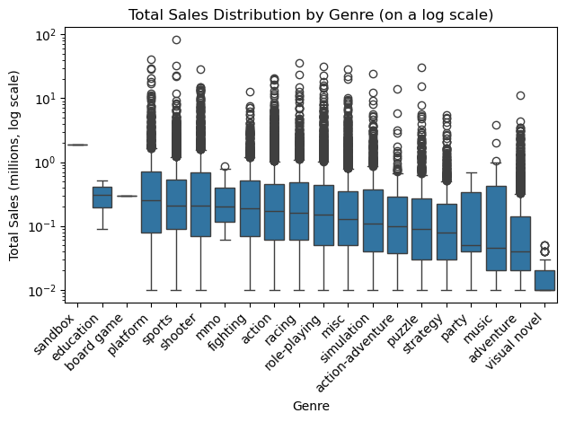

```python
import matplotlib.pyplot as plt
import seaborn as sns #simple boxplot (gorgeous)
import scipy.stats as stats #stat testing
import scikit_posthocs as sp #for post-hoc test
import numpy as np

#Test 1: Checking for Normality or Variance:
#group the values in the genre column
genre_sales_groups = [group["total_sales"].values for genre, group in df.groupby("genre")]
#get the test statistic and pvalue for levene test, which checks whether multiple groups have equal variances
levene_statistic,levene_pvalue = stats.levene(*genre_sales_groups)
print(f"Levene's Test-statistic: {levene_statistic}, P-value: {levene_pvalue}")

#Test 2: Kruskal-Wallis: Do the genres differ in total_sales?
#returns the p-value and h statistic and prints it out
kw_statistic,kw_pvalue = stats.kruskal(*genre_sales_groups)
print(f"Kruskal-Wallis H-statistic: {kw_statistic}, P-value: {kw_pvalue}")

#Test 3: Post-hoc test, which is meaningful since p value of the kruskal-wallis test is <0.05
posthoc_dunn_results = sp.posthoc_dunn(
    df,
    val_col="total_sales",
    group_col="genre",
    p_adjust="bonferroni" #just in case to avoid any possible false positives
)

#the dunns test is hard to read so we get only the signifcant values
#We can do this by using np.triu to get keep only the upper triangle, getting rid of any self comparisons
mask = np.triu(np.ones(posthoc_dunn_results.shape),k=1).astype(bool)
#apply the data_mask to the pvalue matrix, stack() used to convert 2D matrix into a simple 1D list
signficant_values_pairs = posthoc_dunn_results.where(mask).stack()
# only gives the pairs where pvalue is less than 0.05 and we sort them from least to greatest
signifcant_values_pairs = signficant_values_pairs[signficant_values_pairs < 0.05].sort_values()
print("\n")
print(f"The Significant genre pairs (p < 0.05) for the dunns post-hoc test: \n{signifcant_values_pairs}")

#Gorgeous Plot: Boxplot
plt.figure()
#group the rows by genre and columns for total_sales, get median and sort them from highest to lowest
grouped_data=df.groupby("genre")["total_sales"].median().sort_values(ascending=False).index
#draw a box plot per genre and order=grouped_data ensures genres appear left to right based on ranked above
sns.boxplot(data=df, x="genre", y="total_sales", order=grouped_data)

plt.yscale("log") #needed since total_sales is heavily right-skewed
#rotates genre_names by 45 so they are vertical and easier to read (no overlap)
#ha=right ensures the roated text is directly under the tick
plt.xticks(rotation=45,ha="right")

plt.title("Total Sales Distribution by Genre (on a log scale)")
plt.xlabel("Genre")
plt.ylabel("Total Sales (millions, log scale)")
plt.tight_layout()
plt.show()
```

***CONCLUSION***

***Hypothesis Test (Kruskal-Wallis):*** Our Null Hypothesis (H₀) expressed that the sales patterns of video games are similar regardless of their type (No impact on Total Sales). Our alternative hypothesis (Hₐ) regarding sales patterns is that at least one genre has different pricing (Total Sales) from other genres (Yes impact on Total Sales). The application of the Kruskal-Wallis test showed that there is a statistically significant relationship between video game genres and total sales (H = 1498.52, p-value ≈ 9.21 × 10⁻³⁰⁷). As a result, the null hypothesis was rejected because p-value is < 0.05; thus creating a conclusion that genre has a substantial impact on Total Sales.

***Outlier Analysis and Summary:*** Overall, the genre of a game has been identified as a strong indicator of its units sold. Mainstream action-driven genres can sell significantly more than niche genres like visual novel and adventure, although due to a few unique outlier sales of games in both categories, this is difficult to determine using average calculations. The best way to visualize this would be through the boxplot graphic, which shows that the sand box, educational, board, platform and sports games are at the top of the median-sales rank while the adventure and visual novel sit at the bottom. Moreover, all genres have many outlier points associated with their box which represent the small number of exceedingly successful titles that actually raise the average sales of each game's respective genre.

**ii) Platform Vs Sales**

Before performing any hypothesis testing, we first examine summary statistics of total sales by platform to understand how sales are distributed across different gaming systems.

```python
df.groupby("platform")["total_sales"].describe()
```

| platform | count | mean | std | min | 25% | 50% | 75% | max |
| --- | --- | --- | --- | --- | --- | --- | --- | --- |
| 2600 | 133.0 | 0.729925 | 0.917241 | 0.07 | 0.2900 | 0.460 | 0.7800 | 7.81 |
| 3do | 4.0 | 0.047500 | 0.034034 | 0.02 | 0.0200 | 0.040 | 0.0675 | 0.09 |
| 3ds | 691.0 | 0.419161 | 1.255738 | 0.01 | 0.0400 | 0.110 | 0.3000 | 14.60 |
| dc | 53.0 | 0.303962 | 0.465937 | 0.02 | 0.0800 | 0.140 | 0.2900 | 2.42 |
| ds | 2281.0 | 0.357887 | 1.387781 | 0.01 | 0.0400 | 0.100 | 0.2600 | 29.80 |
| gb | 102.0 | 2.520098 | 5.275899 | 0.06 | 0.3000 | 1.120 | 2.0875 | 31.37 |
| gba | 851.0 | 0.375288 | 0.883715 | 0.01 | 0.0500 | 0.150 | 0.3750 | 15.85 |
| gbc | 3.0 | 1.446667 | 0.768462 | 0.56 | 1.2100 | 1.860 | 1.8900 | 1.92 |
| gc | 569.0 | 0.354060 | 0.678751 | 0.01 | 0.0700 | 0.150 | 0.3500 | 7.07 |
| gen | 31.0 | 1.040968 | 1.435252 | 0.03 | 0.0700 | 0.150 | 1.7100 | 6.03 |
| gg | 2.0 | 0.040000 | 0.000000 | 0.04 | 0.0400 | 0.040 | 0.0400 | 0.04 |
| mob | 1.0 | 0.030000 | NaN | 0.03 | 0.0300 | 0.030 | 0.0300 | 0.03 |
| n64 | 323.0 | 0.682724 | 1.308193 | 0.01 | 0.1400 | 0.270 | 0.5900 | 11.89 |
| nes | 104.0 | 2.492115 | 4.967522 | 0.06 | 0.9950 | 1.375 | 2.2000 | 40.24 |
| ng | 12.0 | 0.120000 | 0.082241 | 0.02 | 0.0550 | 0.100 | 0.2000 | 0.25 |
| ns | 241.0 | 0.150332 | 0.240399 | 0.01 | 0.0200 | 0.050 | 0.1500 | 1.89 |
| osx | 1.0 | 0.030000 | NaN | 0.03 | 0.0300 | 0.030 | 0.0300 | 0.03 |
| pc | 1172.0 | 0.230444 | 0.629828 | 0.01 | 0.0200 | 0.040 | 0.1300 | 7.96 |
| pce | 2.0 | 0.080000 | 0.084853 | 0.02 | 0.0500 | 0.080 | 0.1100 | 0.14 |
| pcfx | 1.0 | 0.030000 | NaN | 0.03 | 0.0300 | 0.030 | 0.0300 | 0.03 |
| ps | 1207.0 | 0.608708 | 1.051353 | 0.01 | 0.1000 | 0.260 | 0.6600 | 10.95 |
| ps2 | 2235.0 | 0.567499 | 1.124442 | 0.01 | 0.0800 | 0.230 | 0.5500 | 20.81 |
| ps3 | 1451.0 | 0.675830 | 1.361661 | 0.01 | 0.0900 | 0.250 | 0.7300 | 20.32 |
| ps4 | 946.0 | 0.575571 | 1.519799 | 0.01 | 0.0325 | 0.100 | 0.3900 | 19.39 |
| psn | 9.0 | 0.423333 | 0.917033 | 0.02 | 0.0300 | 0.060 | 0.1700 | 2.82 |
| psp | 1376.0 | 0.222798 | 0.495597 | 0.01 | 0.0200 | 0.080 | 0.2100 | 7.72 |
| psv | 705.0 | 0.095730 | 0.191619 | 0.01 | 0.0200 | 0.030 | 0.1000 | 2.47 |
| sat | 177.0 | 0.192429 | 0.216336 | 0.02 | 0.0700 | 0.120 | 0.2600 | 1.93 |
| scd | 6.0 | 0.311667 | 0.583144 | 0.05 | 0.0525 | 0.065 | 0.1225 | 1.50 |
| snes | 243.0 | 0.834691 | 1.855538 | 0.01 | 0.1350 | 0.320 | 0.7050 | 20.61 |
| tg16 | 2.0 | 0.080000 | 0.084853 | 0.02 | 0.0500 | 0.080 | 0.1100 | 0.14 |
| vc | 3.0 | 0.116667 | 0.136137 | 0.01 | 0.0400 | 0.070 | 0.1700 | 0.27 |
| wii | 1385.0 | 0.664412 | 3.054963 | 0.01 | 0.0800 | 0.190 | 0.4700 | 82.53 |
| wiiu | 168.0 | 0.517976 | 1.002458 | 0.01 | 0.0600 | 0.190 | 0.5125 | 7.09 |
| ws | 7.0 | 0.204286 | 0.168904 | 0.01 | 0.1000 | 0.180 | 0.2650 | 0.51 |
| ww | 1.0 | 0.250000 | NaN | 0.25 | 0.2500 | 0.250 | 0.2500 | 0.25 |
| x360 | 1345.0 | 0.742677 | 1.582113 | 0.01 | 0.1000 | 0.270 | 0.7200 | 21.81 |
| xb | 845.0 | 0.308817 | 0.529917 | 0.01 | 0.0600 | 0.140 | 0.3400 | 8.49 |
| xbl | 5.0 | 0.040000 | 0.050990 | 0.01 | 0.0100 | 0.020 | 0.0300 | 0.13 |
| xone | 555.0 | 0.469243 | 0.936859 | 0.01 | 0.0400 | 0.120 | 0.4300 | 8.72 |

- **H₀ (Null)**: Mean total sales are equal across all platforms
- **H₁ (Alternative)**: At least one platform has significantly different mean total sales than others

We use Levene’s test to evaluate whether the variance in total sales is similar across different platforms.

```python
from scipy.stats import levene

# split data into platform groups
groups = [g["total_sales"].values for _, g in df.groupby("platform")]

# run Levene’s test for equal variances across platforms
stat, p = levene(*groups)


print(stat, p)
```

```
12.235899962251962 1.0801577776088078e-75
```

ANOVA is used to test whether the average total sales differ across platforms. This helps determine if platform has a significant effect on game sales.

```python
from scipy.stats import f_oneway

groups = []

# loop through each platform group
for name, group in df.groupby("platform"):
    # keep only platforms with enough data points for reliable testing
    if len(group) >= 5:
        groups.append(group["total_sales"].values)

# perform one-way ANOVA across platform groups
f_stat, p_val = f_oneway(*groups)

# strength of differences between group means
print("F-statistic:", f_stat)

# significance of those differences
print("p-value:", p_val)
```

```
F-statistic: 25.228426074848645
p-value: 1.3310069364243527e-132
```

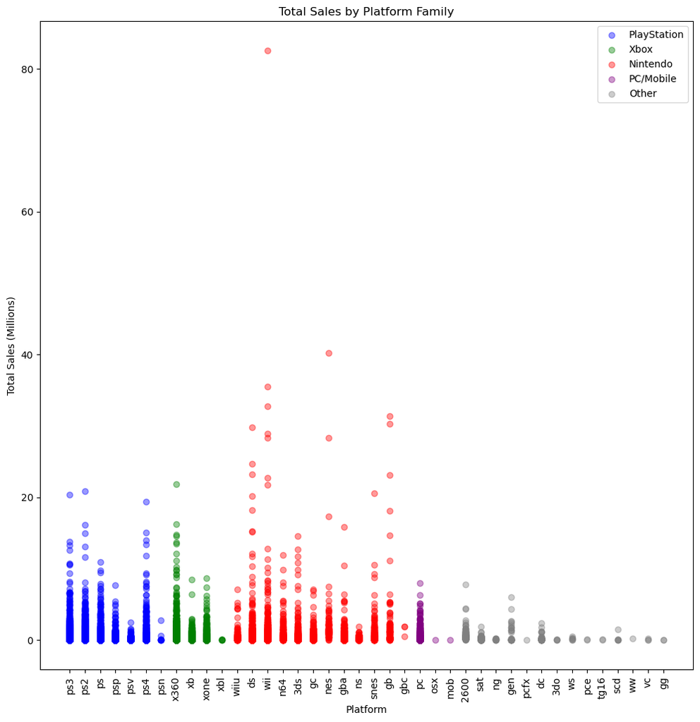

```python
import matplotlib.pyplot as plt

# function that groups each platform into a broader console family category
def get_family(platform):
    ps = ["ps", "ps2", "ps3", "ps4", "psp", "psv", "psn"]
    xbox = ["xb", "x360", "xone", "xbl"]
    nintendo = ["nes", "snes", "n64", "gc", "wii", "wiiu", "ds", "3ds", "gb", "gba", "gbc", "ns"]
    pc = ["pc", "osx", "linux", "mob"]

    if platform in ps:
        return "PlayStation"
    elif platform in xbox:
        return "Xbox"
    elif platform in nintendo:
        return "Nintendo"
    elif platform in pc:
        return "PC/Mobile"
    else:
        return "Other"

# dictionary mapping each platform family to a plot color
family_colors = {
    "PlayStation": "blue",
    "Xbox": "green",
    "Nintendo": "red",
    "PC/Mobile": "purple",
    "Other": "gray"
}

# create a new column that assigns each platform to its family category
df["family"] = df["platform"].apply(get_family)

# recreate color mapping for plotting (redundant but used for visualization)
family_colors = {
    "PlayStation": "blue",
    "Xbox": "green",
    "Nintendo": "red",
    "PC/Mobile": "purple",
    "Other": "gray"
}

plt.figure(figsize=(12,12))

for family, color in family_colors.items():
    subset = df[df["family"] == family]
    plt.scatter(subset["platform"], subset["total_sales"],
                label=family, alpha=0.4, color=color)

plt.xticks(rotation=90)
plt.xlabel("Platform")
plt.ylabel("Total Sales (Millions)")
plt.title("Total Sales by Platform Family")
plt.legend()
plt.show()
```

**CONCLUSION**

**Descriptive Statistics & Dataset Characteristics** : We begin by exploring the main characteristics of the dataset using descriptive statistics. The data shows a strong right-skew in total game sales across platforms, where most games have relatively low sales while a small number of titles account for extremely high values. This suggests that sales are not evenly distributed and are heavily influenced by a few blockbuster games.

**Outliers and Distribution**: One of the most notable outliers is Wii Sports on the Wii platform, which sold approximately 82.53 million units. This value is significantly higher than most other games in the dataset and has a strong effect on the overall distribution. Because of this, the dataset contains high variability within certain platforms, especially those with major hit titles.

**Feature Relationships :** There also appears to be some relationship between categorical features such as platform and the total sales of a game. Certain platforms tend to have higher-performing titles on average, suggesting that platform choice may influence sales outcomes.

**Assumptions and Choice of Analysis Methods:** To compare sales across platforms, we use statistical hypothesis testing methods. We check assumptions such as equal variance using Levene’s test where W = 12.24, p = 1.0801577776088078e-75 which shows variance is not equal across platforms. ANOVA is then used to test whether there are significant differences in mean sales between platforms resulting in F-statistic = 25.228 and p = 1.3310069364243527e-132. The results indicate that the variance in sales is not equal across platforms. Since p < 0.05, we reject H₀ or null hypothesis suggesting that platform does have a statistically significant effect on sales. However, because the data is heavily skewed, contains extreme outliers, and violates equal variance assumptions, the results should be interpreted with caution.

**iii) Old vs New Release Year on Total Sales**

```
Spearman correlation: -0.2008, P-value: 8.3364e-169
Linear Regression slope: -0.02475, R: -0.2050, P-value: 5.8747e-176
Mann-Whitney U: 47630234, P-value: 2.4076e-94
Early era median: 0.19M  |  Late era median: 0.12M
```

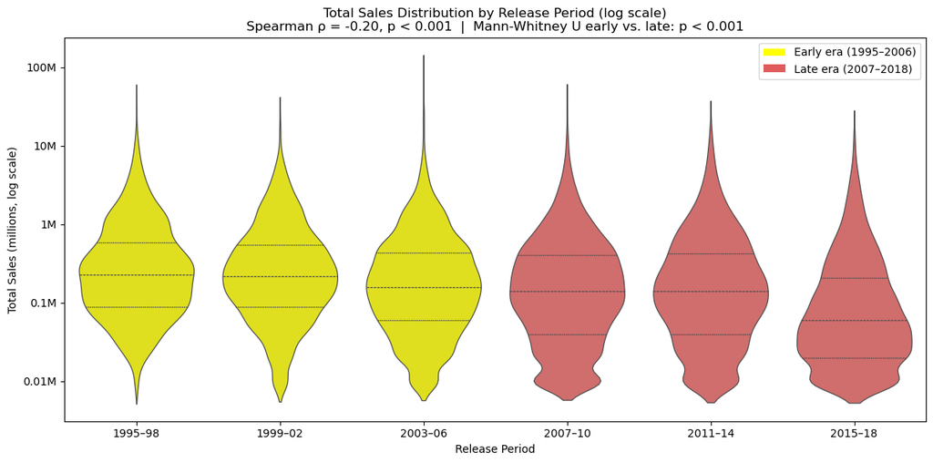

```python
import matplotlib.pyplot as plt
import seaborn as sns
import numpy as np
from scipy.stats import spearmanr, mannwhitneyu, linregress
from matplotlib.patches import Patch

# filter to years
df_year = df[(df["release_year"] >= 1995) & (df["release_year"] <= 2018)].copy()
df_year["release_year"] = df_year["release_year"].astype(int)
df_year["log_sales"] = np.log10(df_year["total_sales"])

# group into 4-year bins so violin shapes are readable
bins   = [1994, 1998, 2002, 2006, 2010, 2014, 2018]
labels = ["1995–98", "1999–02", "2003–06", "2007–10", "2011–14", "2015–18"]
df_year["period"] = pd.cut(df_year["release_year"], bins=bins, labels=labels)

# Spearman Rank Correlation: tests for a monotonic relationship between release year and total sales.
spearman_r = df_year[["release_year", "total_sales"]].corr(method="spearman").loc[
    "release_year", "total_sales"
]
_, spearman_pvalue = spearmanr(df_year["release_year"], df_year["total_sales"])
print(f"Spearman correlation: {spearman_r:.4f}, P-value: {spearman_pvalue:.4e}")

# Linear Regression: Log-transform stabilizes the skewed distribution
# t-test
slope, intercept, r_value, p_value, std_err = linregress(
    df_year["release_year"], df_year["log_sales"]
)
print(f"Linear Regression slope: {slope:.5f}, R: {r_value:.4f}, P-value: {p_value:.4e}")

# Mann-Whitney: two-group test comparing early vs. late era sales
early = df_year[df_year["release_year"] <= 2006]["total_sales"]
late  = df_year[df_year["release_year"] >  2006]["total_sales"]
mw_statistic, mw_pvalue = mannwhitneyu(early, late, alternative="greater")
print(f"Mann-Whitney U: {mw_statistic:.0f}, P-value: {mw_pvalue:.4e}")
print(f"Early era median: {early.median():.2f}M  |  Late era median: {late.median():.2f}M")

# violin plot
df_year["era"] = df_year["release_year"].apply(
    lambda y: "Early (1995–2006)" if y <= 2006 else "Late (2007–2018)"
)

plt.figure(figsize=(12, 6))

sns.violinplot(
    data=df_year,
    x="period",
    y="log_sales",
    hue="era",
    palette={"Early (1995–2006)": "yellow", "Late (2007–2018)": "#E05C5C"},
    dodge=False,
    density_norm="width",
    inner="quart",
    linewidth=0.9,
    legend=False,
)

plt.axvline(x=2.5, color="white", linewidth=1.2, linestyle="--", alpha=0.5)

plt.title(
    "Total Sales Distribution by Release Period (log scale)\n"
    f"Spearman ρ = {spearman_r:.2f}, p < 0.001  |  Mann-Whitney U early vs. late: p < 0.001"
)
plt.xlabel("Release Period")
plt.ylabel("Total Sales (millions, log scale)")
plt.yticks(
    ticks=[-2, -1, 0, 1, 2],
    labels=["0.01M", "0.1M", "1M", "10M", "100M"]
)

legend_elements = [Patch(facecolor="yellow", label="Early era (1995–2006)"),
                   Patch(facecolor="#E05C5C", label="Late era (2007–2018)")]
plt.legend(handles=legend_elements, loc="upper right")

plt.tight_layout()
plt.show()
```

**H₀: Release year has no effect on a game's total global sales. Games from different release eras sell the same amount on average.**

**Conclusion:**

The violin plot makes the pattern clear. The early era violins are wider and sit higher, with more mass above the 0.1M mark, while the late era violins compress and shift downward toward lower sales. The most likely explanation for this is market saturation. The number of games released per year grew from around 216 in 1995 to over 1,500 by 2008 and 2009, which split consumer spending across far more titles at once. This means more competition with roughly the same market size, so each individual game ended up with a smaller share.

This also has implications for the rest of the analysis. Release year should be treated as a control variable in any model built later on, since it can confound both genre and platform comparisons. Older platforms and genres might appear to perform better simply because they faced less competition at the time, not because of anything specifically correlating to the genre or platform itself.

### **5) Primary Analysis**

Based on the results of our exploration, Regression is the best machine learning technique, as we want to predict continuous, real-valued outputs, given that our research question is to predict a video game's total success based on its total sales. Based on the results of the exploration, we can use this technique to predict whether a video game is successful or not based on the total sales of a video game, given that there is some relationship between the total sales of a video game and its features, including genre, platform, and release year, shown in our plots within the data exploration. We can use regression to quantify the importance of each factor in predicting a game's total sales and determine whether one feature carries the most weight or whether they are distributed evenly. This directly answers the research question we stated in the introduction of whether a game will be successful based on total sales, and which factors matter most in determining that success and by how much, or whether they all share the same importance. The specific type of regression technique that best fits our model is **Random Forest Regression**, as it handles many different features, which in our case are a video game's genre, platform, and year in relation to total sales. Importantly, Random Forest Regression builds each tree on a random subset of the entire dataset with all features present, rather than one per feature, because genre, platform, and release year do not independently influence a game’s total sales, this ensures better accuracy and stability across our many features, as it builds these trees, predicts each independently, and averages all tree predictions to produce a final output, making it robust to outliers and overfitting.

```python
import pandas as pd
from sklearn.model_selection import train_test_split
from sklearn.ensemble import RandomForestRegressor

#we're only using genre, platform, and release_year here since those are the
#three factors we're focusing on for our research question from the intro.
#total_sales is what we're actually trying to predict. random forest can't
#take in text values directly so genre/platform will need to get one-hot
#encoded below
game_data=df[["genre","platform","release_year","total_sales"]].dropna()

print(f"Rows BEFORE dropping the missing values: {df.shape[0]}")
print(f"Rows AFTER dropping the missing values: {game_data.shape[0]}")
print(f"Total Rows dropped: {df.shape[0]-game_data.shape[0]}")

#we need to turn genre and platform into dummy columns for the ML models since
#they're categorical, release_year stays as a normal number
#random forest needs numeric input and dummy encoding handles that
features=pd.get_dummies(game_data[["genre","platform","release_year"]],
    columns=["genre","platform"],drop_first=True)
output=game_data["total_sales"]

#just double checking the encoding actually worked how we wanted too
print("The number of genres is:", game_data["genre"].nunique())
print("The nnumber of platforms is:", game_data["platform"].nunique())
print("The total columns after encoding is:", features.shape[1])
print("The first five rows of the features dataframe is:", features.head())

#splitting into training and testing sets, (80/20 split)
#random_state is set so we get the same split every time we need to rerun this
features_train,features_test,target_train,target_test=train_test_split(
    features,output,test_size=0.2,random_state=42)

#building and training the random forest model, using 200 trees
forest_model=RandomForestRegressor(n_estimators=200,random_state=42)
forest_model.fit(features_train,target_train)

#quick sanity check to make sure the model actually trained and everything is
#lined up correctly
print("Model Trained:", forest_model)

print("The Training Features:", features_train.shape, "The Testing Features:", features_test.shape)
print("The Training Target:", target_train.shape, "The testing Target:", target_test.shape)

#grabbing the sales_lvl category for whichever rows ended up in the test set
#so part 2 (evaluation and feature importance) can compare predicted sales
#against poor/low/medium/high/hit
test_sales_levels=df.loc[game_data.index,"sales_lvl"].loc[features_test.index]
```

```
Rows BEFORE dropping the missing values: 19248
Rows AFTER dropping the missing values: 19177
Total Rows dropped: 71
The number of genres is: 20
The nnumber of platforms is: 40
The total columns after encoding is: 59
The first five rows of the features dataframe is:    release_year  genre_action-adventure  genre_adventure  genre_board game  \
0          2012                   False            False             False
1          2012                   False            False             False
2          2012                   False            False             False
3          2008                   False            False             False
4          2008                   False            False             False

   genre_education  genre_fighting  genre_misc  genre_mmo  genre_music  \
0            False           False       False      False        False
1            False           False       False      False        False
2            False           False       False      False        False
3            False           False       False      False        False
4            False           False       False      False        False

   genre_party  ...  platform_tg16  platform_vc  platform_wii  platform_wiiu  \
0        False  ...          False        False         False          False
1        False  ...          False        False         False           True
2        False  ...          False        False         False          False
3        False  ...          False        False         False          False
4        False  ...          False        False         False          False

   platform_ws  platform_ww  platform_x360  platform_xb  platform_xbl  \
0        False        False          False        False         False
1        False        False          False        False         False
2        False        False           True        False         False
3        False        False          False        False         False
4        False        False          False        False         False

   platform_xone
0          False
1          False
2          False
3          False
4          False

[5 rows x 59 columns]
Model Trained: RandomForestRegressor(n_estimators=200, random_state=42)
The Training Features: (15341, 59) The Testing Features: (3836, 59)
The Training Target: (15341,) The testing Target: (3836,)
```

### **Prediction Test and Evaluation**

```python
import numpy as np
from sklearn.metrics import mean_squared_error, r2_score

target_pred = forest_model.predict(features_test)

r2   = r2_score(target_test, target_pred)
mse  = mean_squared_error(target_test, target_pred)
rmse = np.sqrt(mse)

print(f"R²:   {r2:.4f}")
print(f"MSE:  {mse:.4f}")
print(f"RMSE: {rmse:.4f} million units")
print(f"Mean actual sales in test set:    {target_test.mean():.4f}M")
print(f"Mean predicted sales in test set: {target_pred.mean():.4f}M")

imp_df = pd.DataFrame({
    "feature":    features_train.columns.tolist(),
    "importance": forest_model.feature_importances_
})

def group_feature(name):
    if name.startswith("genre_"):    return "genre"
    if name.startswith("platform_"): return "platform"
    return "release_year"

imp_df["group"] = imp_df["feature"].apply(group_feature)

grouped_imp = (imp_df.groupby("group")["importance"]
                     .sum()
                     .reset_index()
                     .sort_values("importance", ascending=False))

print("\nGrouped Feature Importances:")
print(grouped_imp.to_string(index=False))
```

```
R²:   -0.0678
MSE:  1.7684
RMSE: 1.3298 million units
Mean actual sales in test set:    0.5006M
Mean predicted sales in test set: 0.4807M

Grouped Feature Importances:
       group  importance
release_year    0.444076
       genre    0.363616
    platform    0.192307
```

***Evaluation***

The model's R² of −0.0677 tells us that it performs slightly worse than just predicting the mean sales for every game, which means genre, platform, and release year alone are not enough to reliably predict how much a specific game will sell. This is not entirely surprising given what we found in the exploration. Sales are heavily right skewed, where a small number of blockbuster outliers dominate the distribution, and those are extremely hard to predict from these three features alone. The RMSE of 1.33 million units on a test set where the average game sells around 0.50 million units, which was based on the 80/20 test split, reflects how much those outliers are pulling the error up.

Release year (44.4%) came out as the most important predictor, followed by genre (36.4%) and then platform (19.2%). This lines up with the exploration, where the release year analysis showed that market saturation over time had a statistically significant negative effect on per title sales, and the genre analysis showed strong differences in median sales across categories. Platform ended up contributing the least of the three, suggesting that what genre a game belongs to and when it was released matters more to its sales outcome than what console it was on.

The dominance of release year here reinforces the point made in in our exploration that it should be treated as a control variable in any model. A game released in 2008 was competing against over 1,500 other titles that year, while a game from 1998 faced far fewer competition. That competitive context is a significant factor in sales, which is why it ranked above genre despite genre having a larger effect in the raw hypothesis tests.

### **6) Visualization**

To better understand which factors contributed most to the Random Forest model’s predictions, we visualize the feature importance scores of the top 15 features. Feature importance represents how much each feature contributed to the model’s decision-making process when predicting total game sales. A higher importance score indicates that the model relied more heavily on that feature during prediction.

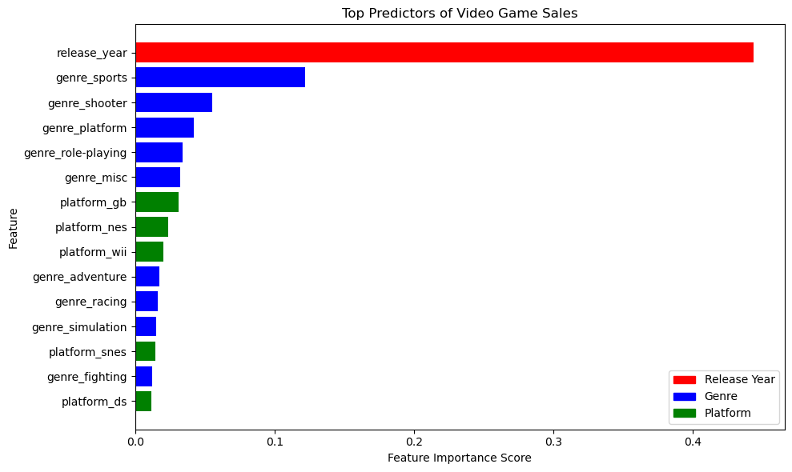

```python
import matplotlib.pyplot as plt

# Sort features by importance and select top 15 features
top_features = imp_df.sort_values("importance", ascending=False).head(15)

# Assign colors by each feature category
colors = []
for feature in top_features["feature"]:
    if "year" in feature:
        colors.append("red")
    elif "genre" in feature:
        colors.append("blue")
    else:
        colors.append("green")

# Create horizontal bar chart
plt.figure(figsize=(10, 6))

plt.barh(top_features["feature"], top_features["importance"], color=colors)

# Flip y-axis so highest importance is at the top
plt.gca().invert_yaxis()

# Legend
plt.legend(handles=[
    plt.Rectangle((0,0),1,1, color="red", label="Release Year"),
    plt.Rectangle((0,0),1,1, color="blue", label="Genre"),
    plt.Rectangle((0,0),1,1, color="green", label="Platform")
], loc="lower right")

# labels and title
plt.xlabel("Feature Importance Score")
plt.ylabel("Feature")
plt.title("Top Predictors of Video Game Sales")

plt.tight_layout()
plt.show()
```

The chart shows that release year related information contributed the most to the Random Forest model, followed by genre and platform variables. This suggests that changes in the video game market over time have a larger influence on sales predictions than the platform alone. Genre features also played an important role, which supports the earlier analysis showing differences in sales performance across genres. Although platform was included as a predictor, it contributed less than release year and genre, suggesting that the success of a game depends on multiple factors beyond the console it was released on.

### **7) Conclusion**

An uninformed reader going through our project would be surprised to find that how video games sell can be influenced by their release year, genre, and platform. They would also be informed about how the video game market works and how competitive it is to achieve success over decades, as older games often do better in terms of sales than newer ones, showing that newer does not always bring more success.

A more informed reader who already knows more about video games can take both visible and hidden insights from this project. One example is that release year is the strongest predictor of sales, which is surprising because games are often thought to be driven more by their genre, which attracts a specific type of audience. However, our data shows that the release year, which indicates how competitive the market was at that time, is actually more influential. In addition, besides the mainstream genres, they can also see which specific genres perform well and which do not. Furthermore, they can also see the difference in platform sales and how older platforms surprisingly outperformed newer ones.

Overall, after researching and analyzing our data on the total sales of video games based on release year, platform, and genre, we wanted to see if there was a difference or equal importance of influence in predicting a game's total success, which can be helpful for game developers and companies to use as a guideline to better understand what factors drive the sales and success of a video game.